# Data 624 Homework 6

Anthony Pagan

3/22/2020

Figure 8.31 shows the ACFs for 36 random numbers, 360 random numbers and 1,000 random numbers.

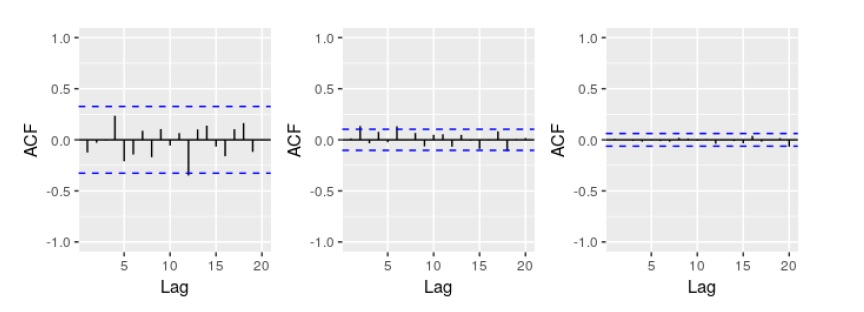

## 1) ACF

### (a) Explain Differences

Explain the differences among these figures. Do they all indicate that the data are white noise?

**In each figure the h or maximum lag is 20 and the T or number of observations are increasing. For the data to be white noise 95% of the of the spikes in the ACF to lie within ±2/√T±2/T. All 3 series confirm this fact and are therefore white noise.**

### (b) Critical Values

Why are the critical values at different distances from the mean of zero? Why are the autocorrelations different in each figure when they each refer to white noise?

**The critical values are different because the number of observations are increasing. The law of large numbers say that the average will get closer to the expected vaalues as the number of trials increase. For white noise we expect autocorrelation to be close to zero.**

## 2) Non-Stationary Series

A classic example of a non-stationary series is the daily closing IBM stock price series (data set ibmclose). Use R to plot the daily closing prices for IBM stock and the ACF and PACF. Explain how each plot shows that the series is non-stationary and should be differenced.

**In non-stationary data the ACS plot will decrease slowly which we can clearly see here. The Pacf plot shows relationship between yt and yt-k after removing affects of lags. The first lag is expected to be above the critical threshold as it has nothing to remove, but the remaing lags are within the 95% threashold. Since the ACF is decaying and there a significant spike in lag p in the Pacf , but none beyond lag p, the data may follow ARIMA(p,d,0)**

```
## Series: ibmclose
## ARIMA(0,1,0)
##
## sigma^2 estimated as 52.62:  log likelihood=-1251.37
## AIC=2504.74   AICc=2504.75   BIC=2508.64
```

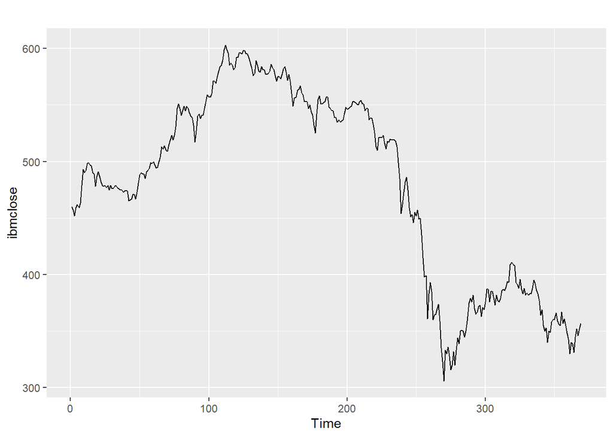

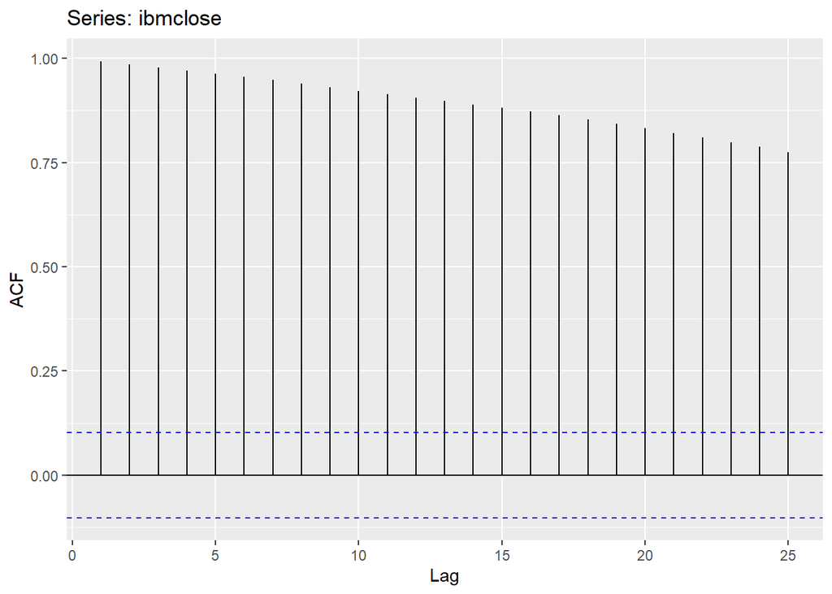

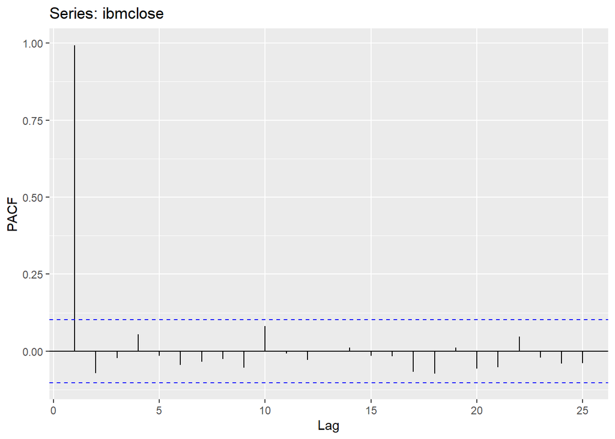

## 3) Box-Cox Transform

For the following series, find an appropriate Box-Cox transformation and order of differencing in order to obtain stationary data.

**Transform Function**

```r
transform<-function (x)
{
compt<-cbind(x=x,
      "log" =log(x),
      "diff" =diff(log(x),12),
      "Double diff"=diff(diff(log(x),12),1))%>%
  autoplot(facets=TRUE)+
  xlab("Year") + ylab("")+
  ggtitle(x)


x %>% diff()%>% ggtsdisplay(main="")
diff(diff(log(x),12),1)%>% ggtsdisplay(main="")

auto.arima(x)
Box.test(x)

checkresiduals(auto.arima(x))

compt
}
```

### (a) usnetelec

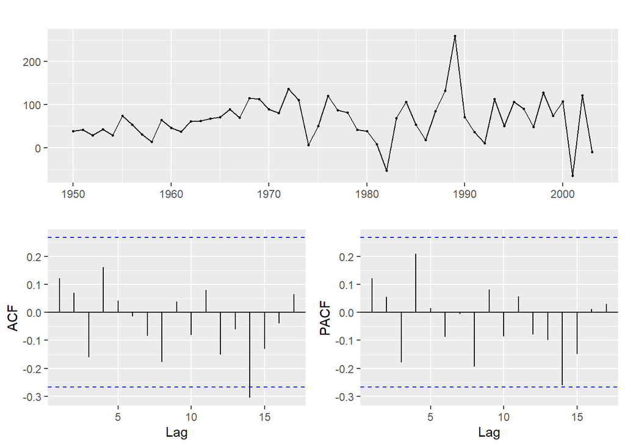

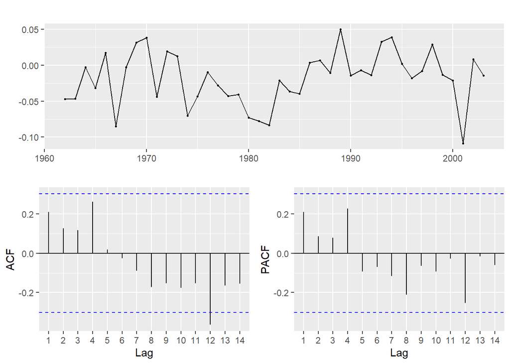

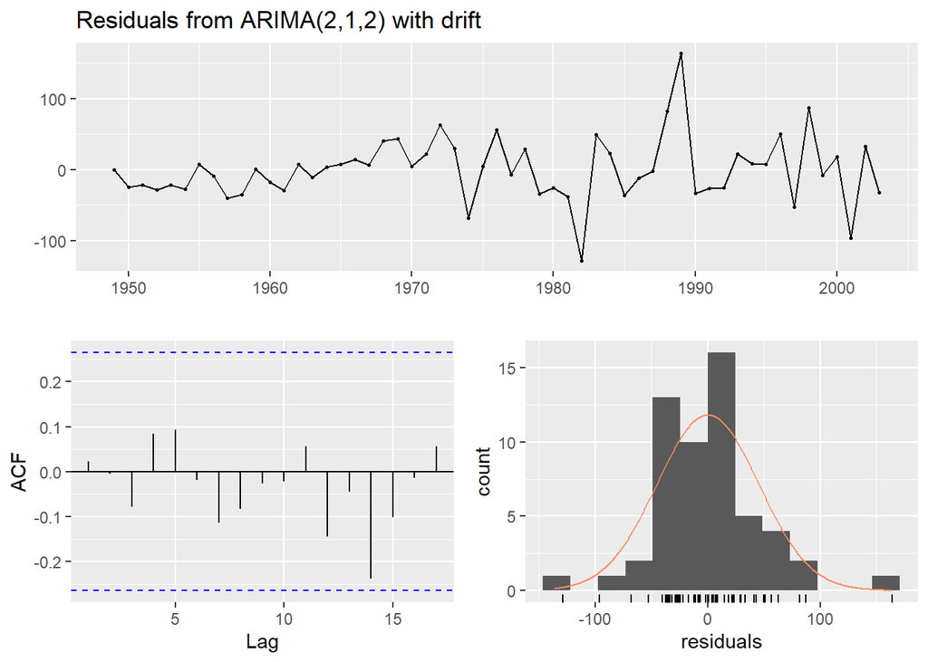

```
##
##  Ljung-Box test
##
## data:  Residuals from ARIMA(2,1,2) with drift
## Q* = 2.7945, df = 5, p-value = 0.7316
##
## Model df: 5.   Total lags used: 10
```

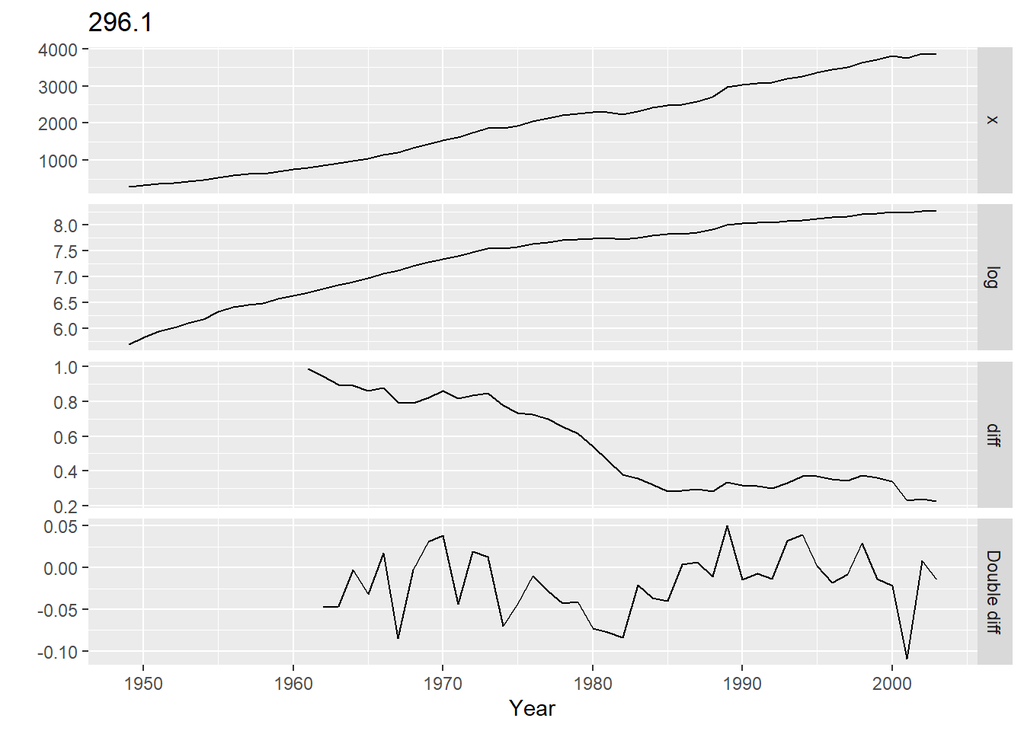

### (b) usgdp

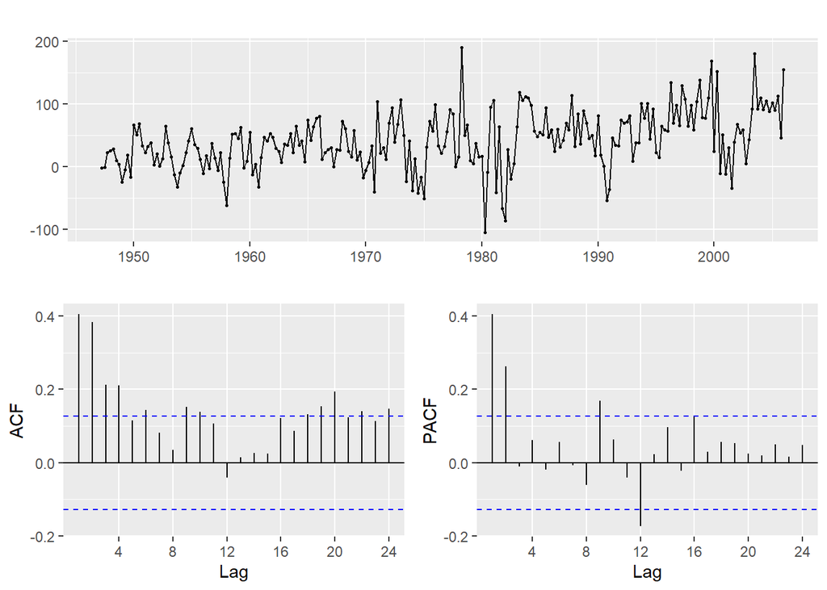

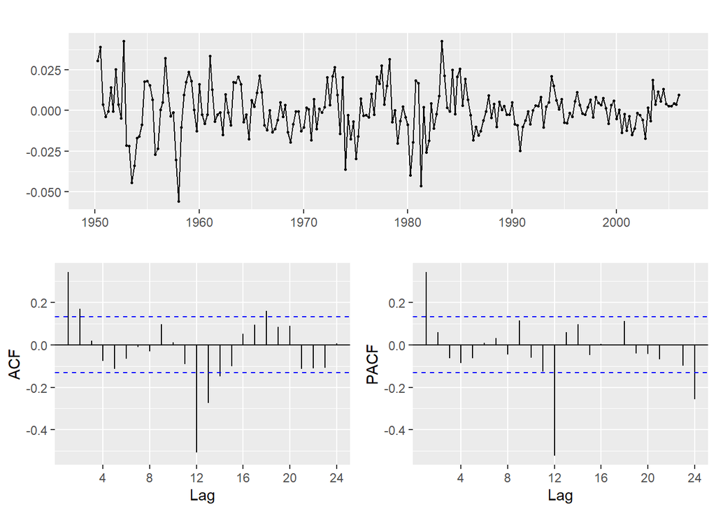

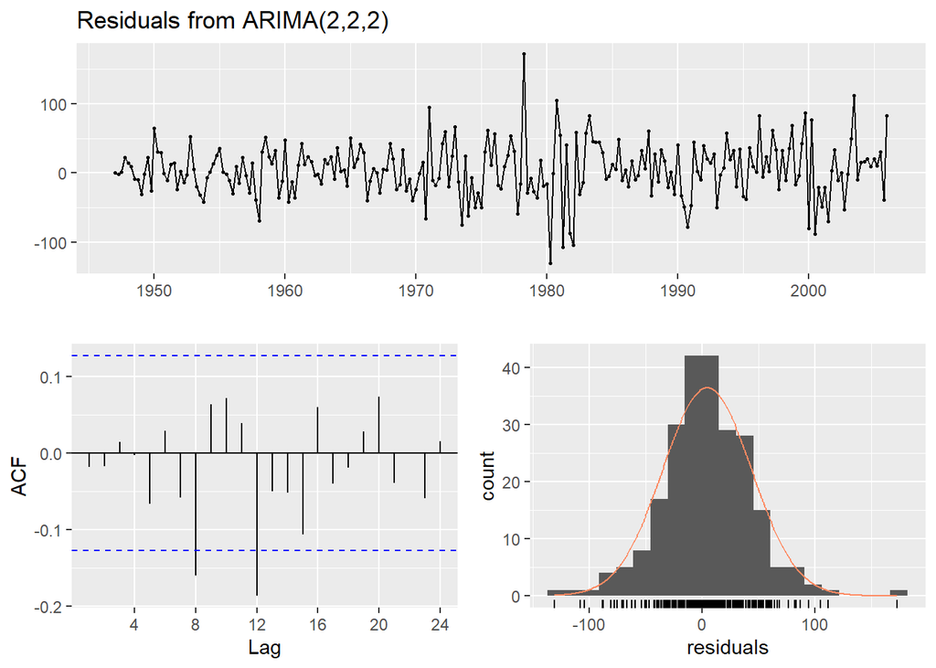

```
##
##  Ljung-Box test
##
## data:  Residuals from ARIMA(2,2,2)
## Q* = 8.6247, df = 4, p-value = 0.0712
##
## Model df: 4.   Total lags used: 8
```

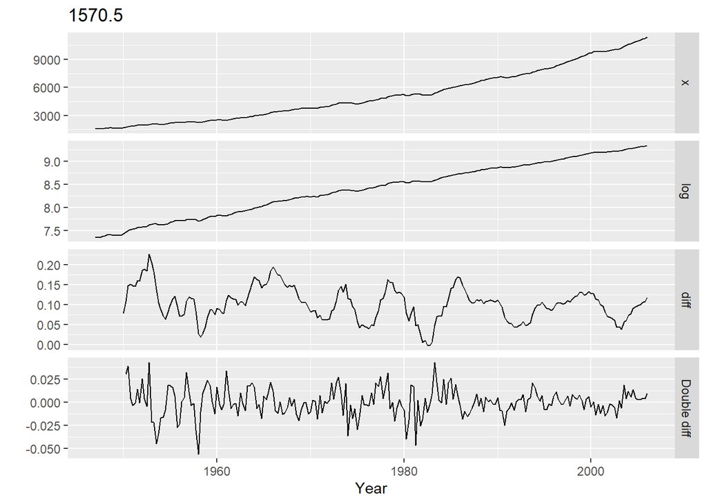

### (c) mcopper

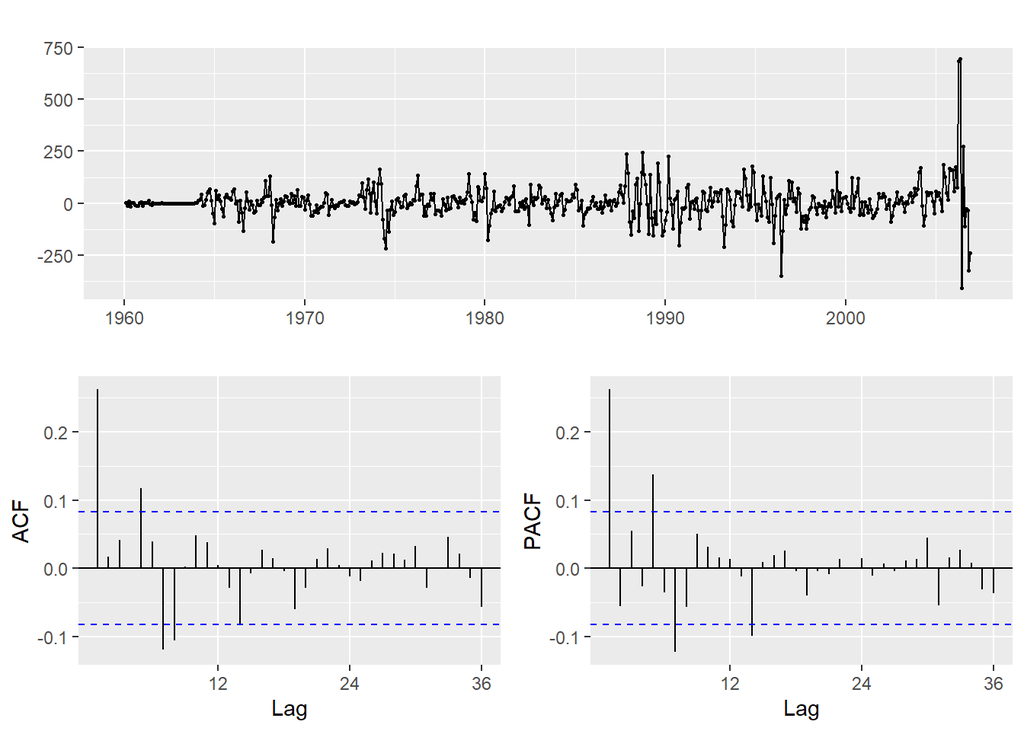

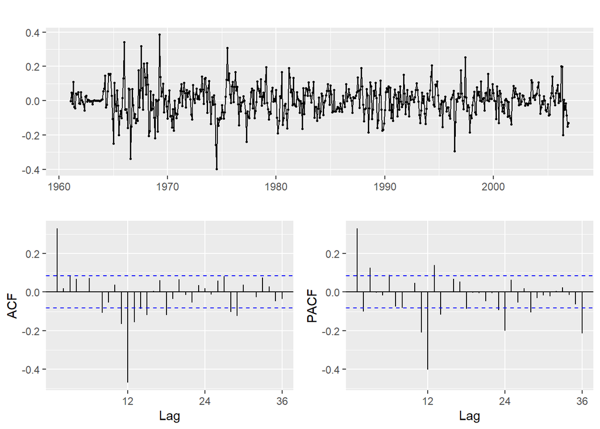

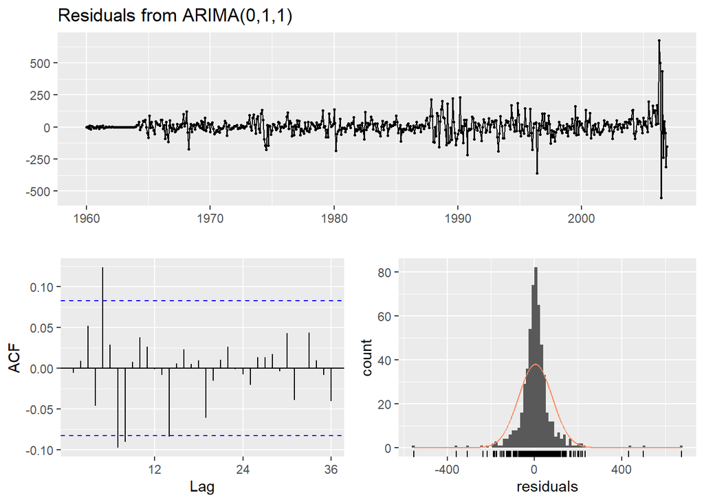

```
##
##  Ljung-Box test
##
## data:  Residuals from ARIMA(0,1,1)
## Q* = 30.716, df = 23, p-value = 0.1299
##
## Model df: 1.   Total lags used: 24
```

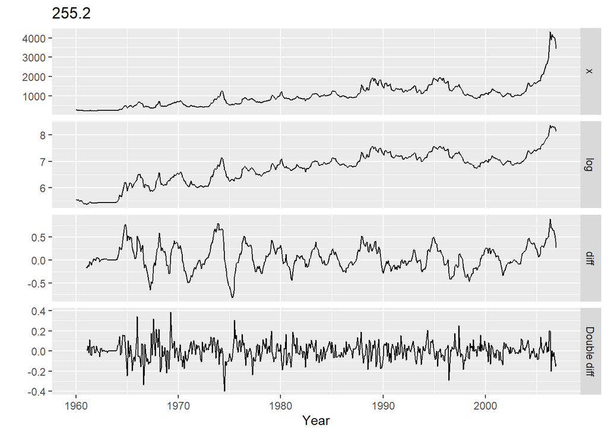

### (d) enplanements

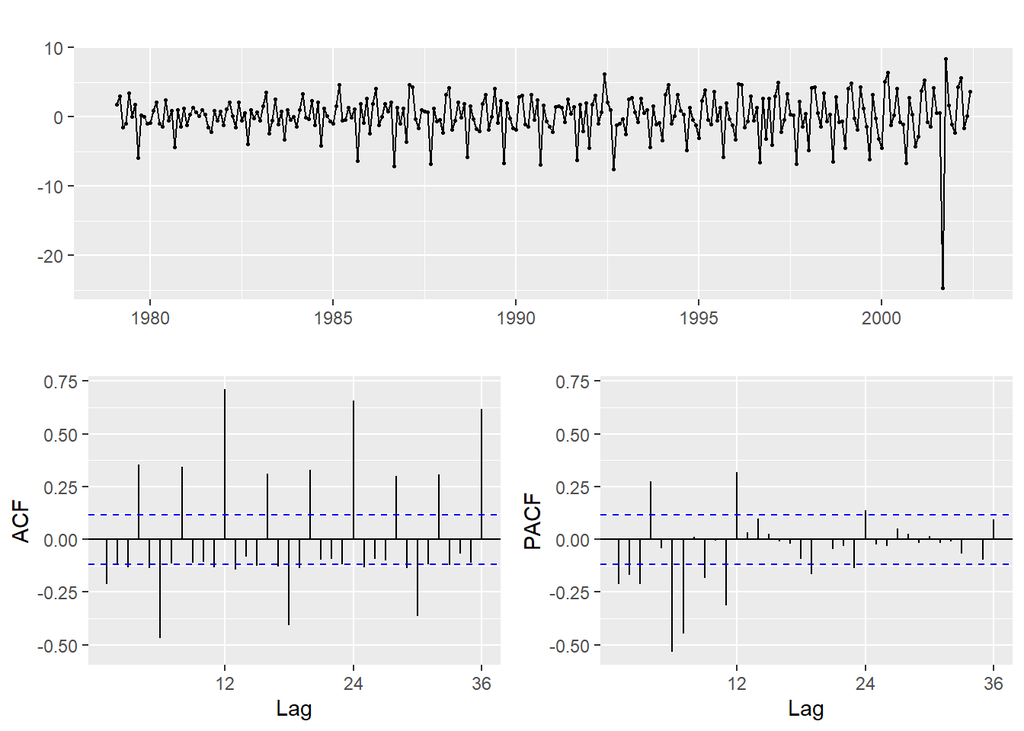

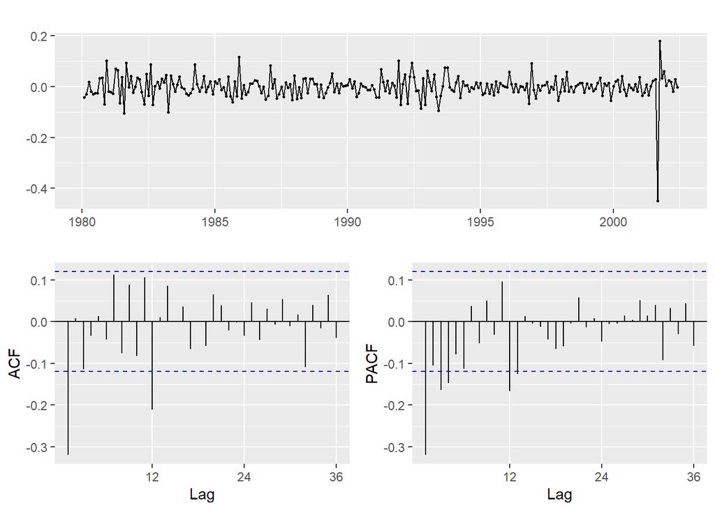

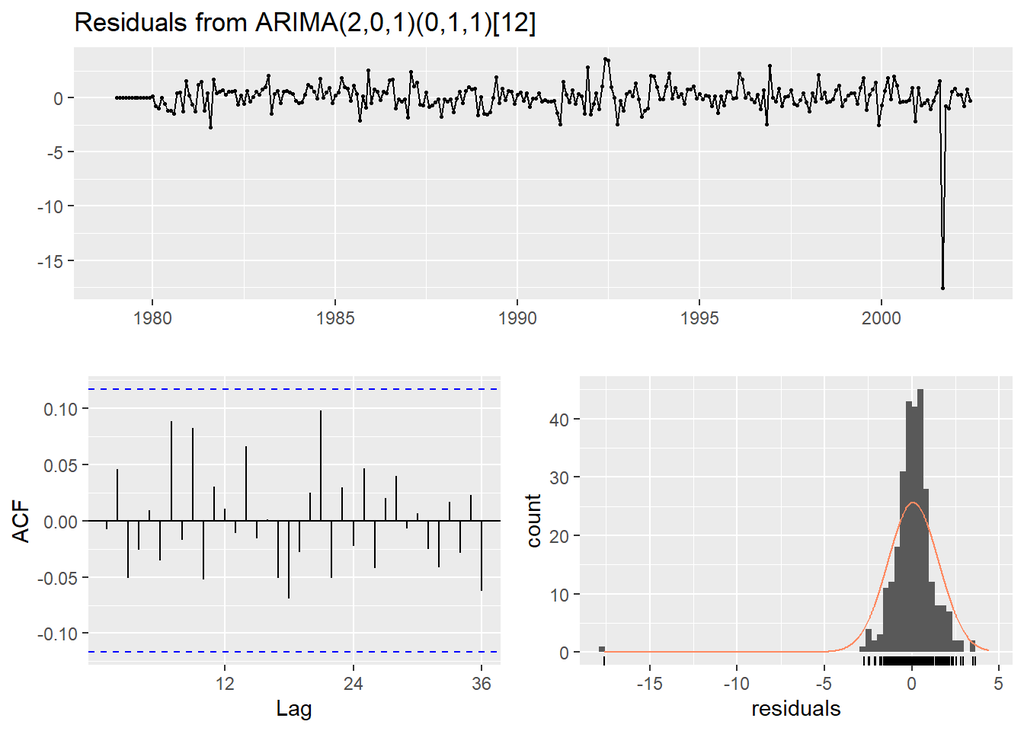

```
##
##  Ljung-Box test
##
## data:  Residuals from ARIMA(2,0,1)(0,1,1)[12]
## Q* = 15.625, df = 20, p-value = 0.7396
##
## Model df: 4.   Total lags used: 24
```

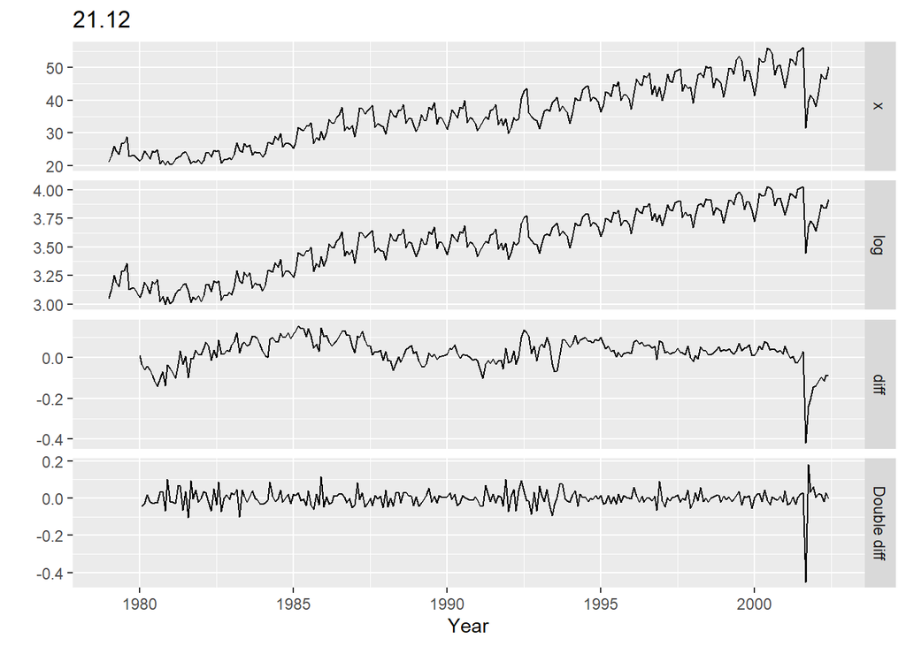

### (e) visitors

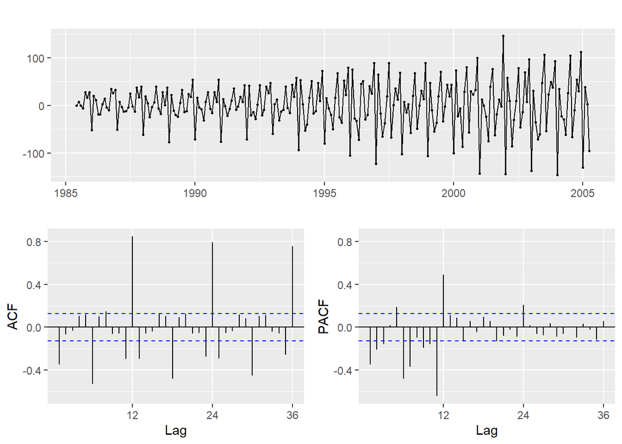

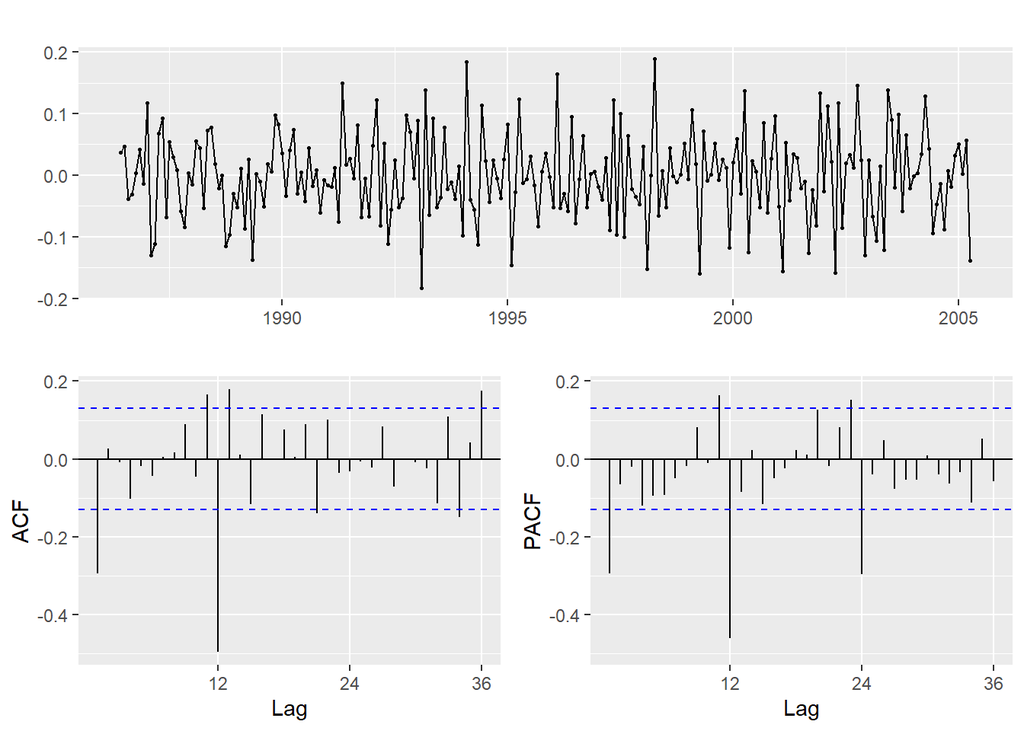

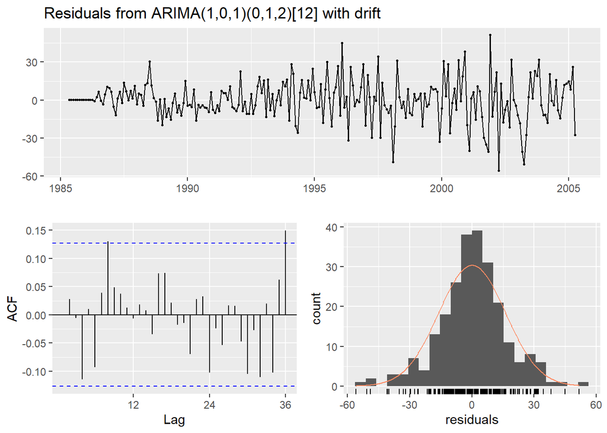

```
##
##  Ljung-Box test
##
## data:  Residuals from ARIMA(1,0,1)(0,1,2)[12] with drift
## Q* = 19.26, df = 19, p-value = 0.4403
##
## Model df: 5.   Total lags used: 24
```

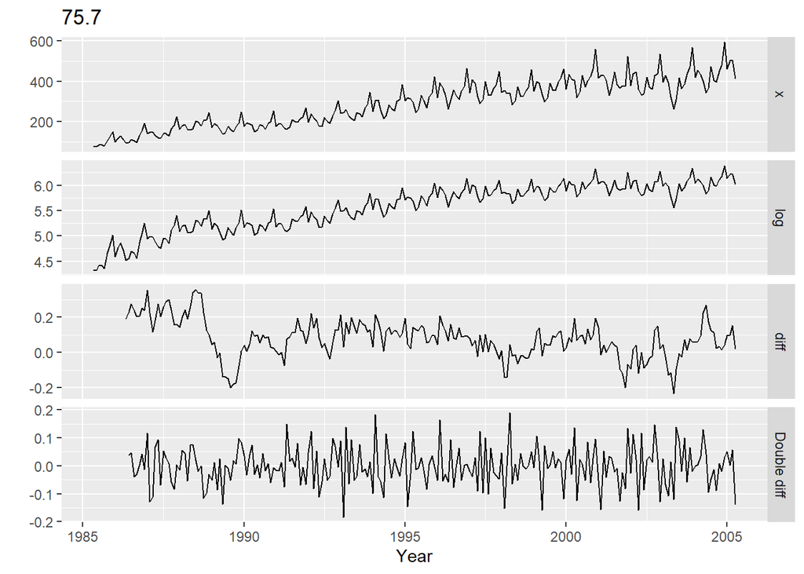

## 5) Differencing

For your retail data (from Exercise 3 in Section 2.10), find the appropriate order of differencing (after transformation if necessary) to obtain stationary data.

**Using the transform fuction created earlier auto.arima provides best model: ARIMA(1,0,2)(0,1,1)[12] with drift**

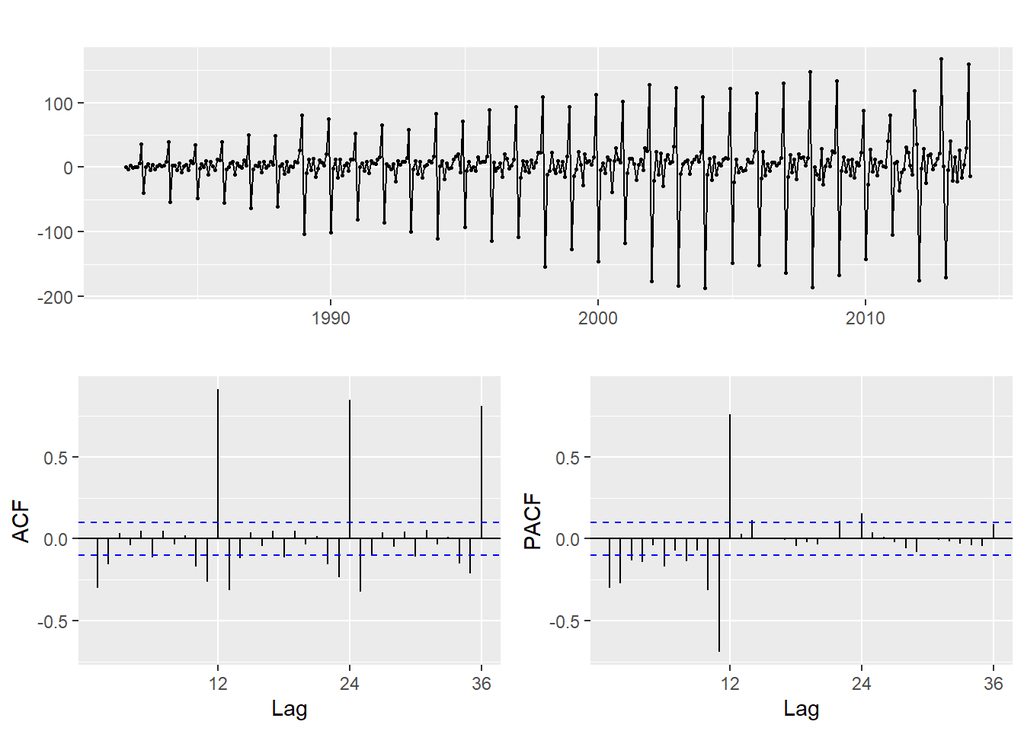

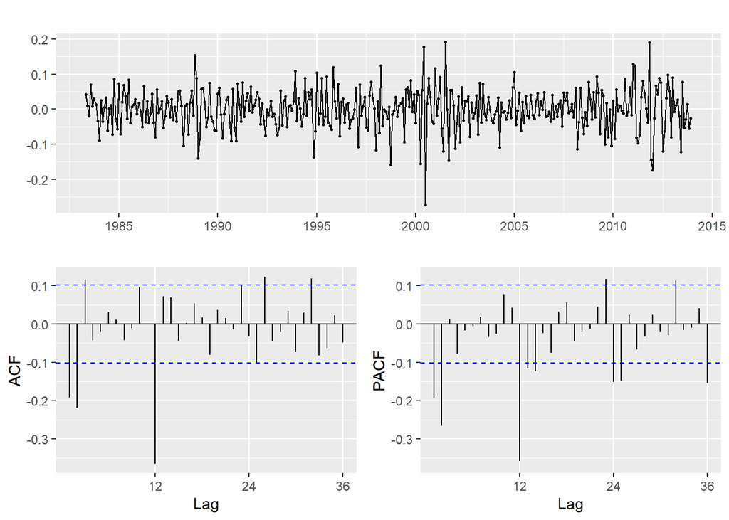

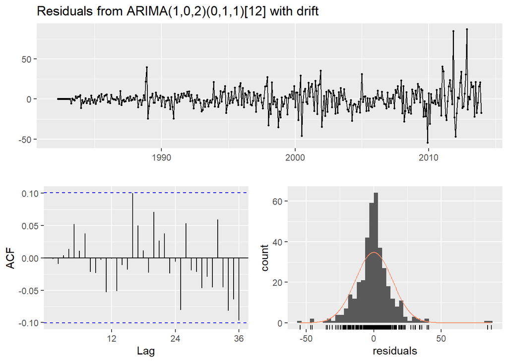

```
##
##  Ljung-Box test
##
## data:  Residuals from ARIMA(1,0,2)(0,1,1)[12] with drift
## Q* = 12.946, df = 19, p-value = 0.8413
##
## Model df: 5.   Total lags used: 24
```

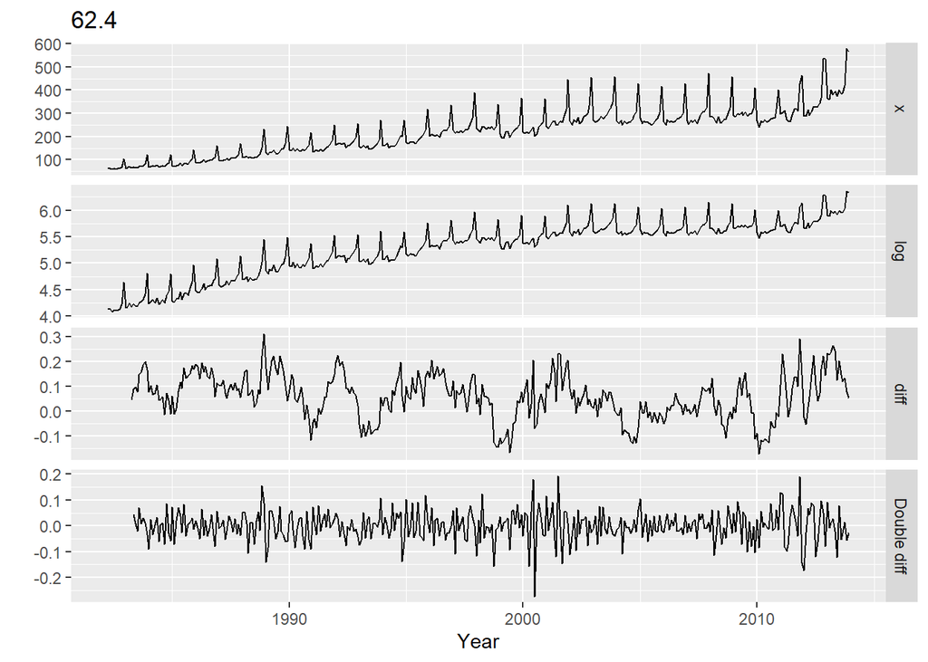

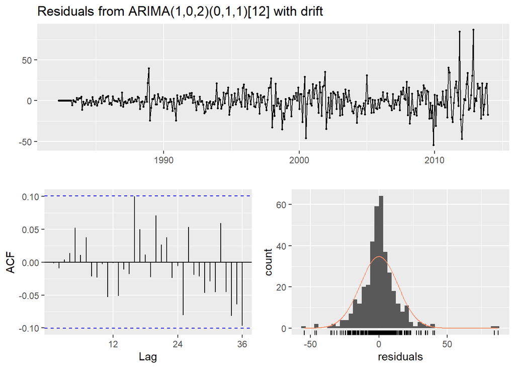

```
##
##  Ljung-Box test
##
## data:  Residuals from ARIMA(1,0,2)(0,1,1)[12] with drift
## Q* = 12.946, df = 19, p-value = 0.8413
##
## Model df: 5.   Total lags used: 24
```

## 6) ARIMA

Use R to simulate and plot some data from simple ARIMA models.

### (a) AR(1)

Use the following R code to generate data from an AR(1) model with ϕ1=0.6 and σ2=1. The process starts with y1=0 .

```r
y <- ts(numeric(100))
e <- rnorm(100)
for(i in 2:100)
  y[i] <- 0.6*y[i-1] + e[i]

autoplot(y)
```

[output not shown]

```r
auto.arima(y)
```

```
## Series: y
## ARIMA(1,0,0) with non-zero mean
##
## Coefficients:
##          ar1    mean
##       0.5441  0.3848
## s.e.  0.0834  0.2357
##
## sigma^2 estimated as 1.206:  log likelihood=-150.41
## AIC=306.83   AICc=307.08   BIC=314.64
```

```r
fit1<-Arima(y, order=c(1,0,0))
fit1
```

```
## Series: y
## ARIMA(1,0,0) with non-zero mean
##
## Coefficients:
##          ar1    mean
##       0.5441  0.3848
## s.e.  0.0834  0.2357
##
## sigma^2 estimated as 1.206:  log likelihood=-150.41
## AIC=306.83   AICc=307.08   BIC=314.64
```

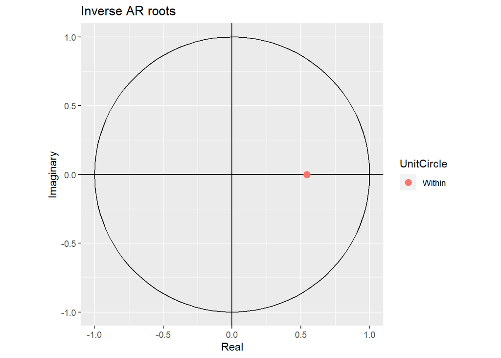

```r
autoplot(fit1)
```

### (b) Time Plot AR(1)

Produce a time plot for the series. How does the plot change as you change ϕ1?

**The change to ϕ1 adds a bit of a long-term uptrend to the plot although it is not seasonaly consistent**

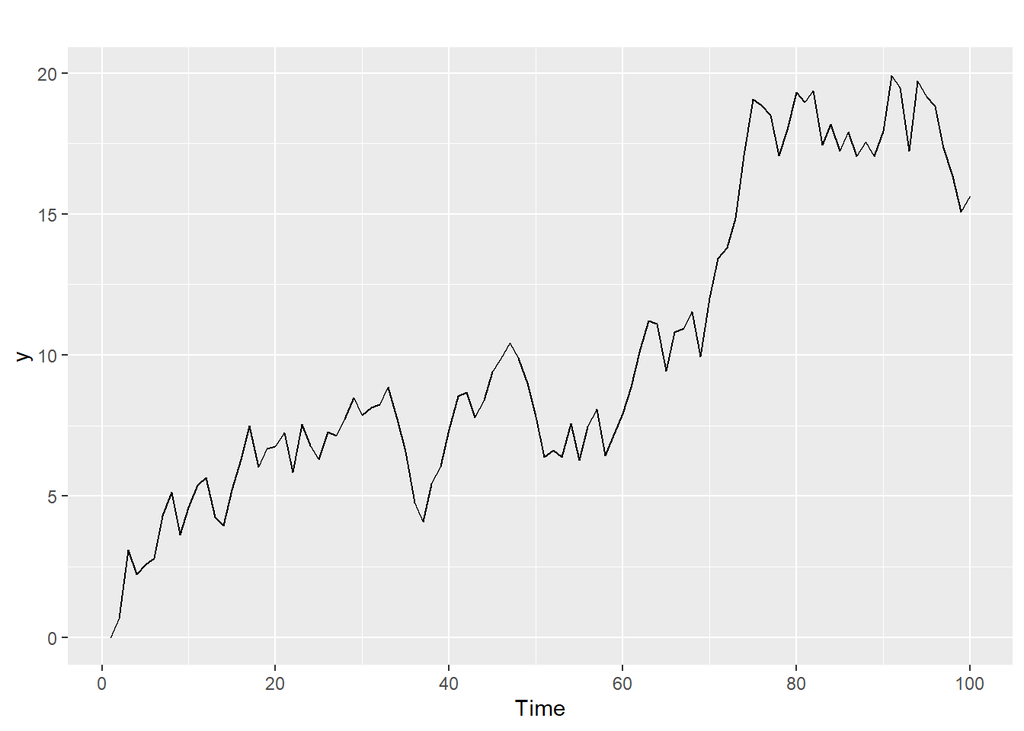